# Zivilgesellschaft im Netzwerk

Author

Sophia Luhr

# ÜBERBLICK

1.) Cooperation-Netzwerk: Verbindung über gemeinsame Kooperationen  
2.) Issue-Netzwerk: Verbindung über gemeinsame Themen  
3.) Participation-Netzwerk: Verbindung über gemeinsame Teilnahme an Veranstaltungen  
Knotenattribute:  
- Name  
- ID  
- Ego-Alter  
- Gründungsjahr  
- Mitgliederzahl  
- Akteurstypus  
- Van-der-Meer-Typus  
- Pötzsch-Typus

# PAKETE

```r
library(igraph)   # Netzwerkanalyse
library(dplyr)    # Datenmanipulation
library(tidyr)    # Datenumstrukturierung
library(readxl)   # Excel einlesen
library(writexl)  # Excel exportieren
library(plotly)   # interaktive Visualisierung
library(stringr)  # Textbearbeitung
```

# DATEN LADEN

```r
path <- "/Users/sophialuhr/Desktop/1. Semester/Netzwerke/Code/data.xlsx"

eig       <- read_excel(path, "Eigenschaften")
iss       <- read_excel(path, "Interessen")
part      <- read_excel(path, "Veranstaltungen")
coop      <- read_excel(path, "Kooperationen")
```

# ISSUE-NETZWERK + PARTICIPATION-NETZWERK: Projektionen

```r
# Funktion: Projektion bipartites Netzwerk
make_bipartite_projection <- function(df, projection = c("actors", "items")) {
  projection <- match.arg(projection)

  # Umwandlung wide- zu long-Format
  long <- df %>%
    pivot_longer(-Name, names_to = "item", values_to = "value") %>%
    filter(value == 1)

  # Erstellung bipartiter Graph
  g <- graph_from_data_frame(long %>% select(Name, item), directed = FALSE)

  # Kennzeichnung Knotentyp (TRUE = Akteure / FALSE = Items)
  V(g)$type <- V(g)$name %in% df$Name

  # Projektion
  proj <- bipartite_projection(g)
  g_actors <- proj$proj2
  g_items  <- proj$proj1

  if (projection == "actors") {
    return(g_actors)
  } else {
    return(g_items)
  }
}

# Issue-Netzwerk
g_iss_actor   <- make_bipartite_projection(iss, "actors")
g_iss_items  <- make_bipartite_projection(iss, "items")

# Participation-Netzwerk
g_part_actor  <- make_bipartite_projection(part, "actors")
g_part_items <- make_bipartite_projection(part, "items")
```

# KOOPERATIONSNETZWERK: Adjazenzmatrix (Akteur-Akteur)

```r
# Umwandlung Excel-Tabelle in Matrix
coop_mat <- as.matrix(coop[, -1])
coop_mat[is.na(coop_mat)] <- 0 # NA = 0

# Zeilen- und Spaltennamen setzen
rownames(coop_mat) <- coop$Name
colnames(coop_mat) <- coop$Name

# Erstellung des Netzwerks
g_coop <- graph_from_adjacency_matrix(coop_mat, mode = "undirected", diag = FALSE)
```

# ATTRIBUTE AN KNOTEN

```r
add_attributes <- function(g, eig) {

  # Matching Akteure
  m <- match(V(g)$name, eig$Name)

  # Attribute hinzufügen
  V(g)$ID  <- eig$`ID`[m]
  V(g)$Ego_Alter  <- eig$`Ego-Alter`[m]
  V(g)$Gruendungsjahr  <- eig$`Gründungsjahr`[m]
  V(g)$Mitgliederzahl <- as.numeric(eig$Mitgliederzahl[m])
  V(g)$Akteurstypus   <- eig$Akteurstypus[m]
  V(g)$Meer_Typus     <- eig$`Van der Meer-Typus`[m]
  V(g)$Poetzsch_Typus   <- eig$`Pötzsch-Typus`[m]

  g
}

g_coop       <- add_attributes(g_coop, eig)
g_iss_actor  <- add_attributes(g_iss_actor, eig)
g_part_actor <- add_attributes(g_part_actor, eig)
```

# COMMUNITY-DETECTION

Die Communities werden mithilfe des Louvain-Algorithmus identifiziert.  
Community: eine Gruppe von Knoten, die untereinander stärker verbunden sind als mit dem restlichen Netzwerk

```r
# 1.) Cooperation-Netzwerk
comm_coop_obj <- cluster_louvain(g_coop)

comm_coop <- data.frame(
  Name = V(g_coop)$name,
  Community = membership(comm_coop_obj)
)

comm_coop <- comm_coop %>%
  left_join(eig, by = "Name")

comm_sizes_coop <- as.data.frame(table(comm_coop$Community))
colnames(comm_sizes_coop) <- c("Community","Anzahl_Akteure")

# 2.) Issue-Netzwerk (Akteur-Projektion)
comm_iss_obj <- cluster_louvain(g_iss_actor)

comm_iss <- data.frame(
  Name = V(g_iss_actor)$name,
  Community = membership(comm_iss_obj)
)

comm_iss <- comm_iss %>%
  left_join(eig, by = "Name")

comm_sizes_iss <- as.data.frame(table(comm_iss$Community))
colnames(comm_sizes_iss) <- c("Community","Anzahl_Akteure")

# 2.1.) Issue-Netzwerk (Themen-Projektion)

comm_iss_items_obj <- cluster_louvain(g_iss_items)

comm_iss_items <- data.frame(
  Thema = V(g_iss_items)$name,
  Community = membership(comm_iss_items_obj)
)

comm_sizes_iss_items <- as.data.frame(table(comm_iss_items$Community))
colnames(comm_sizes_iss_items) <- c("Community","Anzahl_Themen")

# 3.) Participation-Netzwerk (Akteur-Projektion)
comm_part_obj <- cluster_louvain(g_part_actor)

comm_part <- data.frame(
  Name = V(g_part_actor)$name,
  Community = membership(comm_part_obj)
)

comm_part <- comm_part %>%
  left_join(eig, by = "Name")

comm_sizes_part <- as.data.frame(table(comm_part$Community))
colnames(comm_sizes_part) <- c("Community","Anzahl_Akteure")

# 3.1.) Participation-Netzwerk (Veranstaltungsprojektion)
comm_part_items_obj <- cluster_louvain(g_part_items)

comm_part_items <- data.frame(
Veranstaltung = V(g_part_items)$name,
  Community = membership(comm_part_items_obj)
)

comm_sizes_part_items <- as.data.frame(table(comm_part_items$Community))
colnames(comm_sizes_part_items) <- c("Community","Anzahl_Veranstaltungen")
```

# VISUALISIERUNG

Layout: Fruchtermann-Reingold  
Knotengröße: Degree

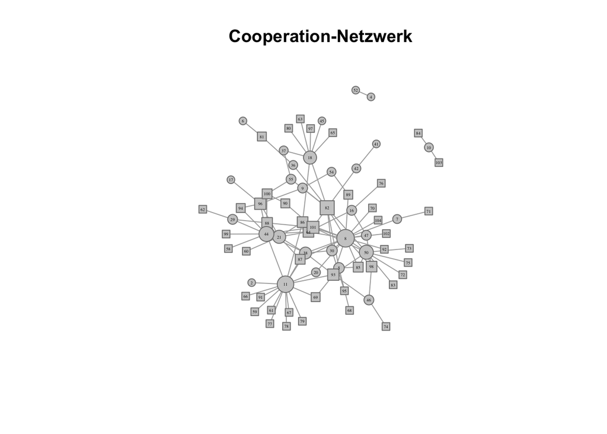

```r
# 1.) Cooperation-Netzwerk
# Vorbereitung
deg   <- degree(g_coop)
vsize <- 4 + 2.5 * sqrt(deg)
set.seed(123)
lay <- layout_with_fr(g_coop)
alter_ego <- ifelse(
  V(g_coop)$Ego_Alter == "Ego",
  "circle",
  "square"
)

# Ohne Communities
plot(
  g_coop,
  layout = lay,
  vertex.color = "grey80",
  vertex.size = vsize,
  vertex.shape = alter_ego,
  vertex.frame.color = "grey50",
  vertex.label = V(g_coop)$ID,
  vertex.label.cex = 0.3,
  vertex.label.color = "black",
  main = "Cooperation-Netzwerk"
)
```

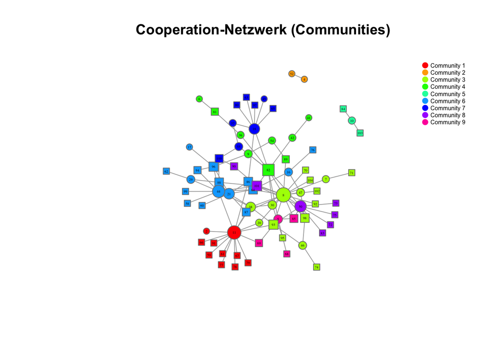

```r
# Communities
cols_coop <- rainbow(length(unique(membership(comm_coop_obj))))

par(xpd = TRUE)

plot(
  g_coop,
  layout = lay,
  vertex.color = cols_coop[membership(comm_coop_obj)],
  vertex.size = vsize,
  vertex.shape = alter_ego,
  vertex.frame.color = "grey50",
  vertex.label = V(g_coop)$ID,
  vertex.label.cex = 0.3,
  vertex.label.color = "black",
  main = "Cooperation-Netzwerk (Communities)"
)

legend(
  "topright",
  legend = paste("Community", sort(unique(membership(comm_coop_obj)))),
  col = cols_coop,
  pch = 19,
  pt.cex = 1,
  cex = 0.5,
  bty = "n"
)
```

```r
# Abbildung speichern
png("cooperation_network_communities.png", width = 2000, height = 1500, res = 300)
plot(
  g_coop,
  layout = lay,
  vertex.color = cols_coop[membership(comm_coop_obj)],
  vertex.size = vsize,
  vertex.shape = alter_ego,
  vertex.frame.color = "grey50",
  vertex.label = V(g_coop)$ID,
  vertex.label.cex = 0.3,
  vertex.label.color = "black",
  main = "Cooperation-Netzwerk (Communities)"
)

legend(
  "topright",
  legend = paste("Community", sort(unique(membership(comm_coop_obj)))),
  col = cols_coop,
  pch = 19,
  pt.cex = 1,
  cex = 0.5,
  bty = "n"
)
dev.off()
```

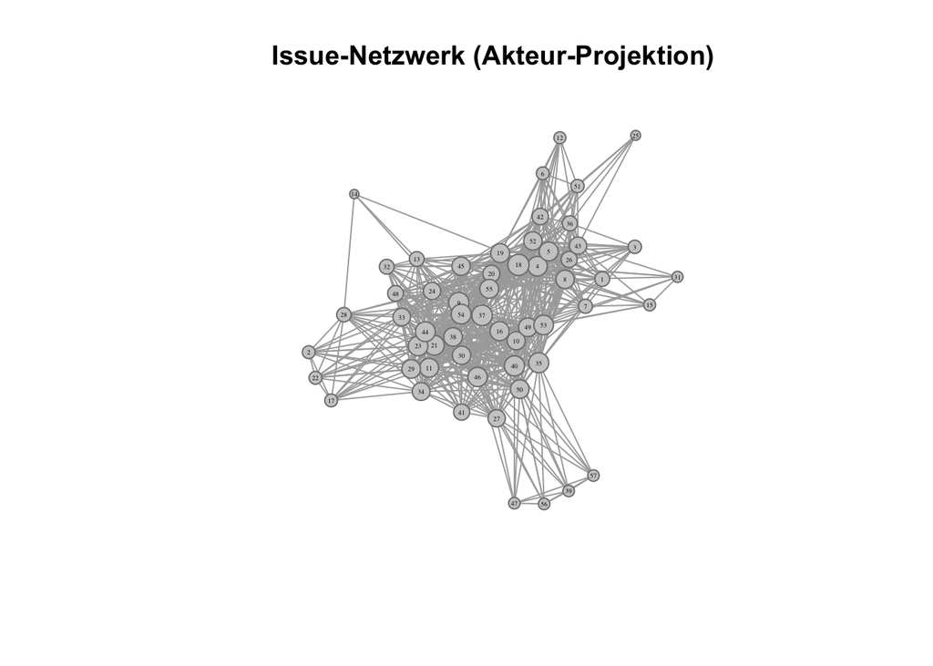

```r
# 2.) Issue-Netzwerk (Akteure)
# Vorbereitung
deg   <- degree(g_iss_actor)
vsize <- 2 + 1.5 * sqrt(deg)
set.seed(123)
lay   <- layout_with_fr(g_iss_actor)

# Akteur-Projektion
plot(
  g_iss_actor,
  layout = lay,
  vertex.color = "grey80",
  vertex.size = vsize,
  vertex.frame.color = "grey50",
  vertex.label = V(g_iss_actor)$ID,
  vertex.label.cex = 0.3,
  vertex.label.color = "black",
  main = "Issue-Netzwerk (Akteur-Projektion)"
)
```

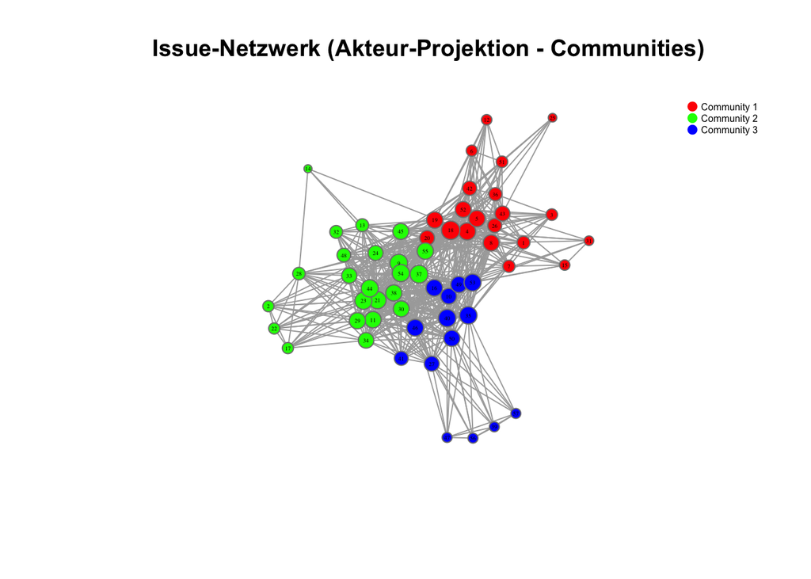

```r
# Communities
cols_iss <- rainbow(length(unique(membership(comm_iss_obj))))

par(xpd = TRUE)

plot(
  g_iss_actor,
  layout = lay,
  vertex.color = cols_iss[membership(comm_iss_obj)],
  vertex.size = vsize,
  vertex.frame.color = "grey50",
  vertex.label = V(g_iss_actor)$ID,
  vertex.label.cex = 0.3,
  vertex.label.color = "black",
  main = "Issue-Netzwerk (Akteur-Projektion - Communities)"
)

legend(
  "topright",
  legend = paste("Community", sort(unique(membership(comm_iss_obj)))),
  col = cols_iss,
  pch = 19,
  pt.cex = 1,
  cex = 0.5,
  bty = "n"
)
```

```r
# Abbildung speichern
png("issue_network_actors_communities.png", width = 2000, height = 1500, res = 300)
plot(
  g_iss_actor,
  layout = lay,
  vertex.color = cols_iss[membership(comm_iss_obj)],
  vertex.size = vsize,
  vertex.frame.color = "grey50",
  vertex.label = V(g_iss_actor)$ID,
  vertex.label.cex = 0.3,
  vertex.label.color = "black",
  main = "Issue-Netzwerk (Akteur-Projektion - Communities)"
)
legend(
  "topright",
  legend = paste("Community", sort(unique(membership(comm_iss_obj)))),
  col = cols_iss,
  pch = 19,
  pt.cex = 1,
  cex = 0.5,
  bty = "n"
)
dev.off()
```

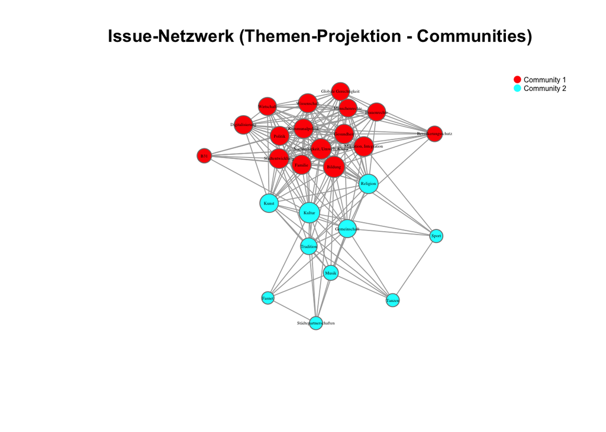

```r
# 2.1.) Issue-Netzwerk (Themen-Projektion - Communities)
# Vorbereitung
deg   <- degree(g_iss_items)
vsize <- 4 + 3 * sqrt(deg)
set.seed(123)
lay <- layout_with_fr(g_iss_items)

# Plot
cols_iss_items <- rainbow(length(unique(membership(comm_iss_items_obj))))

par(xpd = TRUE)

plot(
  g_iss_items,
  layout = lay,
  vertex.color = cols_iss_items[membership(comm_iss_items_obj)],
  vertex.size = vsize,
  vertex.frame.color = "grey50",
  vertex.label = V(g_iss_items)$ID,
  vertex.label.cex = 0.3,
  vertex.label.color = "black",
  main = "Issue-Netzwerk (Themen-Projektion - Communities)"
)

legend(
  "topright",
  legend = paste("Community", sort(unique(membership(comm_iss_items_obj)))),
  col = cols_iss_items,
  pch = 19,
  pt.cex = 1,
  cex = 0.5,
  bty = "n"
)
```

```r
# Abbildung speichern
png("issue_network_themen_communities.png", width = 2000, height = 1500, res = 300)
plot(
  g_iss_items,
  layout = lay,
  vertex.color = cols_iss_items[membership(comm_iss_items_obj)],
  vertex.size = vsize,
  vertex.frame.color = "grey50",
  vertex.label = V(g_iss_items)$ID,
  vertex.label.cex = 0.3,
  vertex.label.color = "black",
  main = "Issue-Netzwerk (Themen-Projektion - Communities)"
)

legend(
  "topright",
  legend = paste("Community", sort(unique(membership(comm_iss_items_obj)))),
  col = cols_iss_items,
  pch = 19,
  pt.cex = 1,
  cex = 0.5,
  bty = "n"
)
dev.off()
```

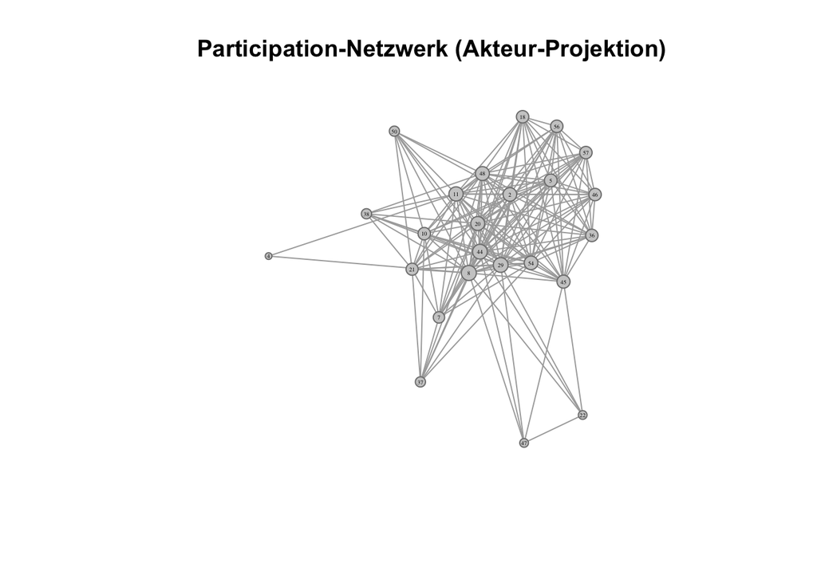

```r
# 3.) Participation-Netzwerk
deg   <- degree(g_part_actor)
vsize <- 2 + 1.5 * sqrt(deg)
set.seed(123)
lay   <- layout_with_fr(g_part_actor)

# Akteur-Projektion
plot(
  g_part_actor,
  layout = lay,
  vertex.color = "grey80",
  vertex.size = vsize,
  vertex.frame.color = "grey50",
  vertex.label = V(g_part_actor)$ID,
  vertex.label.cex = 0.3,
  vertex.label.color = "black",
  main = "Participation-Netzwerk (Akteur-Projektion)"
)
```

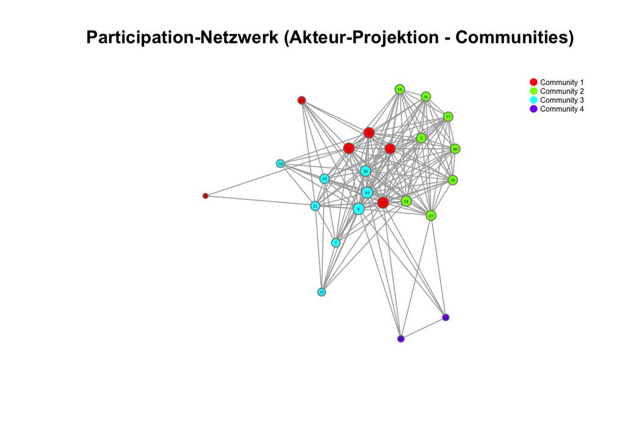

```r
# Communities
cols_part_actor <- rainbow(length(unique(membership(comm_part_obj))))

par(xpd = TRUE)

plot(
  g_part_actor,
  layout = lay,
  vertex.color = cols_part_actor[membership(comm_part_obj)],
  vertex.size = vsize,
  vertex.frame.color = "grey50",
  vertex.label = V(g_part_actor)$ID,
  vertex.label.cex = 0.3,
  vertex.label.color = "black",
  main = "Participation-Netzwerk (Akteur-Projektion - Communities)"
)

legend(
  "topright",
  legend = paste("Community", sort(unique(membership(comm_part_obj)))),
  col = cols_part_actor,
  pch = 19,
  pt.cex = 1,
  cex = 0.5,
  bty = "n"
)
```

```r
# Abbildung speichern
png("participation_network_actors_communities.png", width = 2000, height = 1500, res = 300)
plot(
  g_part_actor,
  layout = lay,
  vertex.color = cols_part_actor[membership(comm_part_obj)],
  vertex.size = vsize,
  vertex.frame.color = "grey50",
  vertex.label = V(g_part_actor)$ID,
  vertex.label.cex = 0.3,
  vertex.label.color = "black",
  main = "Participation-Netzwerk (Akteur-Projektion - Communities)"
)

legend(
  "topright",
  legend = paste("Community", sort(unique(membership(comm_part_obj)))),
  col = cols_part_actor,
  pch = 19,
  pt.cex = 1,
  cex = 0.5,
  bty = "n"
)
dev.off()
```

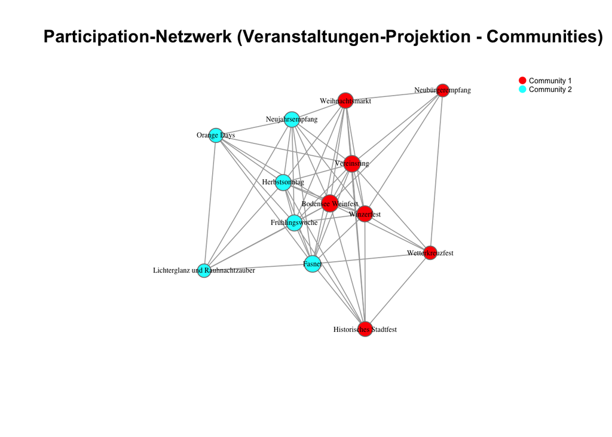

```r
# 3.1.) Participation-Netzwerk (Veranstaltungsprojektion - Communities)
deg   <- degree(g_part_items)
vsize <- 4 + 3 * sqrt(deg)
set.seed(123)
lay   <- layout_with_fr(g_part_items)

# Plot
cols_part_items <- rainbow(length(unique(membership(comm_part_items_obj))))

par(xpd = TRUE)

plot(
  g_part_items,
  vertex.color =  cols_part_items[membership(comm_part_items_obj)],
  vertex.size = vsize,
  vertex.frame.color = "grey50",
  vertex.label.cex = 0.5,
  vertex.label.color = "black",
  main = "Participation-Netzwerk (Veranstaltungen-Projektion - Communities)"
)

legend(
  "topright",
  legend = paste("Community", sort(unique(membership(comm_part_items_obj)))),
  col = cols_part_items,
  pch = 19,
  pt.cex = 1,
  cex = 0.5,
  bty = "n"
)
```

```r
# Abbildung speichern
png("participation_network_veranstaltungen_communities.png", width = 2000, height = 1500, res = 300)
plot(
  g_part_items,
  vertex.color = cols_part_items[membership(comm_part_items_obj)],
  vertex.size = vsize,
  vertex.frame.color = "grey50",
  vertex.label.cex = 0.5,
  vertex.label.color = "black",
  main = "Participation-Netzwerk (Veranstaltungen-Projektion - Communities)"
)

legend(
  "topright",
  legend = paste("Community",
  sort(unique(membership(comm_part_items_obj)))),
  col = cols_part_items,
  pch = 19,
  pt.cex = 1,
  cex = 0.5,
  bty = "n"
)
dev.off()
```

# NETZWERKSTRUKTUR

- Anzahl der Knoten
- Anzahl der Kanten
- Netzwerkdichte: Verhältnis der vorhanden zu allen möglichen Verbindungen
- Anzahl der Komponenten: Eine Komponente bezeichnet eine maximal zusammenhängende Teilmenge von Knoten, innerhalb derer zwischen allen Knoten Pfade existieren.
- Anzahl der Communities: s. oben
- Durchschnittliche Pfadlänge: Schritte, die im Durchschnitt notwendig sind, um beliebige Akteure im Netzwerk zu verbinden
- Clustering-Koeffizient (Transitivität): misst, wie stark sich Knoten, die über gemeinsame Nachbarn verbunden sind, auch untereinander verbinden
- Median Degree

```r
netzwerke_struktur_export <- data.frame(
  Netzwerk = c("Kooperation", "Issue", "Participation"),

  # Anzahl Knoten
  Knoten = c(
    vcount(g_coop),
    vcount(g_iss_actor),
    vcount(g_part_actor)
  ),

  # Anzahl Kanten
  Kanten = c(
    ecount(g_coop),
    ecount(g_iss_actor),
    ecount(g_part_actor)
  ),

  # Netzwerkdichte
  Dichte = c(
    edge_density(g_coop),
    edge_density(g_iss_actor),
    edge_density(g_part_actor)
  ),

  # Komponenten
  Komponenten = c(
    components(g_coop)$no,
    components(g_iss_actor)$no,
    components(g_part_actor)$no
  ),

  # Communities
  Communities = c(
    length(comm_coop_obj),
    length(comm_iss_obj),
    length(comm_part_obj)
  ),

  # Durchschnittliche Pfadlänge
  Durchschnittliche_Pfadlaenge = c(
    mean_distance(g_coop, directed = FALSE, unconnected = TRUE),
    mean_distance(g_iss_actor, directed = FALSE, unconnected = TRUE),
    mean_distance(g_part_actor, directed = FALSE, unconnected = TRUE)
  ),

  # Clustering-Koeffizient
  Transitivitaet = c(
    transitivity(g_coop, type = "global", isolates = "zero"),
    transitivity(g_iss_actor, type = "global", isolates = "zero"),
    transitivity(g_part_actor, type = "global", isolates = "zero")
  ),

  # Median Degree
  Median_Degree = c(
    median(degree(g_coop)),
    median(degree(g_iss_actor)),
    median(degree(g_part_actor))
  )
)
```

# ZENTRALITÄTEN

- Degree: Wie viele direkte Verbindungen hat ein Knoten?
- Betweenness: Wie oft liegt Knoten auf den kürzesten Pfaden zwischen anderen Knoten?
- Closeness: Wie nah ist ein Knoten über die kürzesten Pfade zu allen anderen Knoten im Netzwerk positioniert?
- Eigenvector: Wie stark ist der Knoten mit anderen zentralen Knoten verbunden?

```r
# 1.) Cooperation-Netzwerk
centralities_coop_export <- data.frame(
  ID          = V(g_coop)$ID,
  Name        = V(g_coop)$name,
  Community   = membership(comm_coop_obj),
  Degree      = degree(g_coop),
  Betweenness = betweenness(g_coop, normalized = TRUE),
  Closeness   = closeness(g_coop, normalized = TRUE),
  Eigenvector = eigen_centrality(g_coop)$vector
)

# 2.) Issue-Netzwerk
centralities_iss_export <- data.frame(
  ID          = V(g_iss_actor)$ID,
  Name      = V(g_iss_actor)$name,
  Community   = membership(comm_iss_obj),
  Degree      = degree(g_iss_actor),
  Betweenness = betweenness(g_iss_actor, normalized = TRUE),
  Closeness   = closeness(g_iss_actor, normalized = TRUE),
  Eigenvector = eigen_centrality(g_iss_actor)$vector
)

# 3.) Participation-Netzwerk
centralities_part_export <- data.frame(
  ID          = V(g_part_actor)$ID,
  Name        = V(g_part_actor)$name,
  Community   = membership(comm_part_obj),
  Degree      = degree(g_part_actor),
  Betweenness = betweenness(g_part_actor, normalized = TRUE),
  Closeness   = closeness(g_part_actor, normalized = TRUE),
  Eigenvector = eigen_centrality(g_part_actor)$vector
)
```

# VERGLEICH DEGREE-ZENTRALITÄTEN DER DREI NETZWERKE

Vergleichstabelle: Degree-Zentralität der einzelnen Knoten in den drei Netzwerken

```r
vergleich_export <- centralities_coop_export %>%
  select(Name,Degree) %>%
  rename(Degree_Cooperation = Degree) %>%
  left_join(
    centralities_iss_export %>%
      select(Name,Degree) %>%
      rename(Degree_Issue = Degree),
    by="Name"
  ) %>%
  left_join(
    centralities_part_export %>%
      select(Name,Degree) %>%
      rename(Degree_Participation = Degree),
    by="Name"
  )

vergleich_export[is.na(vergleich_export)] <- 0
```

# KORRELATION: DEGREE-ZENTRALITÄT

Korrelationsmatrix der Degree-Zentralität zwischen den verschiedenen Netzwerken: Pearson-Korrelationen  
Wertebereich:  
-1 (perfekter negativer Zusammenhang)  
0 (kein Zusammenhang)  
1 (perfekter positiver Zusammenhang)

```r
cor_matrix_export <- cor(vergleich_export[,2:4], method = "pearson")
```

# Gemeinsame Akteure aller Ebenen

Hier wird die Schnittmenge der Akteure identifiziert, die in allen drei Layern vorkommen.

```r
# Akteurslisten
actors_coop <- V(g_coop)$name
actors_iss  <- V(g_iss_actor)$name
actors_part <- V(g_part_actor)$name

# Schnittmenge
common_actors <- Reduce(intersect, list(actors_coop, actors_iss, actors_part))

# Netzwerke auf diese Akteure beschränken
g_coop_sub <- induced_subgraph(g_coop, vids = common_actors)
g_iss_sub  <- induced_subgraph(g_iss_actor, vids = common_actors)
g_part_sub <- induced_subgraph(g_part_actor, vids = common_actors)

# Zentralitäten für ausgewählte Akteure
deg_coop <- degree(g_coop_sub)
deg_iss  <- degree(g_iss_sub)
deg_part <- degree(g_part_sub)

# Dataframe
df_roles <- data.frame(
  actor = names(deg_coop),
  deg_coop = deg_coop
) %>%
  left_join(
    data.frame(actor = names(deg_iss), deg_iss = deg_iss),
    by = "actor"
  ) %>%
  left_join(
    data.frame(actor = names(deg_part), deg_part = deg_part),
    by = "actor"
  )
```

# ROLLENTYPEN

```r
med_coop <- median(df_roles$deg_coop, na.rm = TRUE)
med_iss  <- median(df_roles$deg_iss, na.rm = TRUE)
med_part <- median(df_roles$deg_part, na.rm = TRUE)

df_roles <- df_roles %>%
  mutate(
    coop_high = deg_coop > med_coop,
    iss_high  = deg_iss  > med_iss,
    part_high = deg_part > med_part,

    Typ = case_when(
      coop_high & iss_high & part_high ~ "multiplex zentral",
      coop_high & iss_high ~ "cooperation + issue zentral",
      coop_high & part_high ~ "cooperation + participation zentral",
      iss_high & part_high ~ "issue + participation zentral",

      coop_high ~ "cooperation zentral",
      iss_high ~ "issue zentral",
      part_high ~ "participation zentral",

      TRUE ~ "peripher"
    )
  )


rollen_export <- df_roles %>%
  count(Typ, name = "Anzahl")

vergleich_export <- vergleich_export %>%
  left_join(df_roles %>% select(actor, Typ),
            by = c("Name" = "actor"))
```

# 3D-STREUDIAGRAMM

x = Degree Cooperation-Netzwerk  
y = Degree Issue-Netzwerk  
z = Degree Participation-Netzwerk

```r
plot_data <- vergleich_export %>%
  filter(Typ != "peripher")

fig <- plot_ly(
  plot_data,
  x = ~Degree_Cooperation,
  y = ~Degree_Issue,
  z = ~Degree_Participation,
  text = ~Name,
  color = ~Typ,
  colors = c(
    "multiplex zentral" = "red",
    "cooperation zentral" = "blue",
    "issue zentral" = "green",
    "participation zentral" = "purple",
    "cooperation + issue zentral" = "orange",
    "cooperation + participation zentral" = "pink",
    "issue + participation zentral" = "cyan"
  ),
  type = "scatter3d",
  mode = "markers+text",
  textposition = "top center"
)

fig
```

[interactive chart not shown]

# Organisationstypus van der Meer und Pötzsch

Inwiefern unterscheidet sich die multiplexe Einbindung von Akteuren nach Organisationstyp?

```r
# Typologien rejoinen
vergleich_export <- vergleich_export %>%
  left_join(eig, by = "Name")

# Finale Tabelle pro Akteur
meer_poetzsch_export <- vergleich_export %>%
  mutate(
    coop_high = Degree_Cooperation > med_coop,
    issue_high = Degree_Issue > med_iss,
    part_high = Degree_Participation > med_part
  ) %>%
  select(
    ID,
    Name,
    Degree_Issue,
    Degree_Participation,
    Degree_Cooperation,
    Typ,
    `Van der Meer-Typus`,
    `Pötzsch-Typus`
  ) %>%
  arrange(Typ)
```

# Kennzahlen nach Van der Meer und Pötzsch

```r
vergleich_common <- vergleich_export %>%
  filter(Name %in% common_actors)

# Kennzahlen: Van der Meer
van_der_meer_means <- vergleich_common %>%
  group_by(`Van der Meer-Typus`) %>%
  summarise(
    n = n(),
    median_coop = median(Degree_Cooperation, na.rm = TRUE),
    median_issue = median(Degree_Issue, na.rm = TRUE),
    median_part = median(Degree_Participation, na.rm = TRUE)
  )

# Kennzahlen: Pötzsch
poetzsch_means <- vergleich_common %>%
  group_by(`Pötzsch-Typus`) %>%
  summarise(
    n = n(),
    median_coop = median(Degree_Cooperation, na.rm = TRUE),
    median_issue = median(Degree_Issue, na.rm = TRUE),
    median_part = median(Degree_Participation, na.rm = TRUE)
  )

# Rollentyp x Organisationstyp - evtl löschen
van_der_meer_rollen <- vergleich_common %>%
  count(Typ, `Van der Meer-Typus`, name = "Anzahl")

poetzsch_rollen <- vergleich_common %>%
  count(Typ, `Pötzsch-Typus`, name = "Anzahl")
```

# EXPORT ERGEBNISSE

```r
export <- list(

  # Netzwerkstruktur
  Netzwerkstruktur = netzwerke_struktur_export,

  # Zentralitäten + Communities
  Zentralitaeten_Cooperation   = centralities_coop_export,
  Zentralitaeten_Issue         = centralities_iss_export,
  Zentralitaeten_Participation = centralities_part_export,

  # Communities (Akteure x Akteure)
  Communitygroessen_Coop = comm_sizes_coop,
  Communitygroessen_Issue_Actor      = comm_sizes_iss,
  Communitygroessen_Part_Actor = comm_sizes_part,

  # Communities (Themen x Themen / Veranstaltungen x Veranstaltungen)
  Communities_Issue_Issue           = comm_iss_items,
  Communitygroessen_Issue_Issue     = comm_sizes_iss_items,
  Communities_Part_Part           = comm_part_items,
  Communitygroessen_Part_Part     = comm_sizes_part_items,

  # Vergleich & Korrelationen
  Vergleich_Degree             = vergleich_export,
  Korrelation_Netzwerke        = as.data.frame(cor_matrix_export),

  # Rollentypen
  Rollentypen                  = rollen_export,
  Rollentypen_Detail           = meer_poetzsch_export,

  # Organisationstypen
  Van_der_Meer_Mittelwerte     = van_der_meer_means,
  Poetzsch_Mittelwerte         = poetzsch_means,

  Van_der_Meer_Rollentypen     = van_der_meer_rollen,
  Poetzsch_Rollentypen         = poetzsch_rollen
)

write_xlsx(export,"/Users/sophialuhr/Desktop/Analyse_Ergebnisse.xlsx")
```